# Solution - One User

### Importing the stopwords from 'stopwords.txt'

```python
#read stopwords.txt
file = open('stopwords.txt', 'r')
contents = file.read()
#print(contents)
file.close()
```

Splitting the text using the delimeter

```python
stopwords = contents.split(',')
len(stopwords)
```

```
119
```

1- The tweets need to be fetched from Twitter as much as possible for each user. For testing purposes, I have attached 10 text files called U1.txt to U10.txt. Each tweet is on a single line in each file.

**Reading tweets for handle U2**

```python
#read tweets for handles U1 to U10
file = open('U2.txt', 'r')
tweetsU1 = file.readlines()
file.close()
```

- Converting all tweets to lower case
- Removing extra spaces, single and double quotes
- Splitting all tweets and adding the words to a list

```python
dictionaryU1 = []
from nltk.tokenize import TweetTokenizer
tknzr = TweetTokenizer()
for twt in tweetsU1:
#   dictionaryU1.extend(twt.lower().strip().strip('"').strip("'").split())
    dictionaryU1.extend(tknzr.tokenize(twt.lower().strip().strip('"').strip("'")))
```

```python
print(len(dictionaryU1))
```

```
21028
```

**Creating a dataframe from the list**

```python
import pandas as pd
df = pd.DataFrame(dictionaryU1,columns=["words"])
df.head(10)
```

|  | words |
| --- | --- |
| 0 | qdos |
| 1 | ultra |
| 2 | gloss |
| 3 | skin |
| 4 | , |
| 5 | screen |
| 6 | protector |
| 7 | , |
| 8 | ear |
| 9 | phone |

2- The words in the dictionary should not contain any letters with more than 2 repetitions. All these repetitions will be replaced with a single character. For example "angryyyyy" will be stored in the dictionary as "angry".

**Applying a lambda function to replace words like angryyyyy with angry**

**Removing extra spaces, if any**

```python
#Import regular expression re
import re
re.sub(r'(.)\1\1+', r'\1', "angryyyyy")
```

```
'angry'
```

```python
df.words = df.words.apply(lambda x: re.sub(r'(.)\1\1+', r'\1', x))
df.words = df.words.apply(lambda x: x.strip())
```

- Stopwords and Vocabulary words

```python
print("Stop words : ",df.words.isin(stopwords).astype(int).sum())
print("Vocab words : ",(~df.words.isin(stopwords)).astype(int).sum())
```

```
Stop words :  1283
Vocab words :  19745
```

3- The dictionary should not contain stop words (e.g. "the", "at", "as", etc.). The list of stop words is attached in a text file file called "stopwords.txt" as a comma separated list.

**Removing the stopwords**

```python
dfNSW = df[~df.words.isin(stopwords)]
```

Removing periods and hyphons and other common special character words

```python
dfNPH = dfNSW[~dfNSW.words.isin(['-',' ','.',',','!',')','(','}','{','[',']',':','&','/','\\',';','"',"'",'$','?'])]
```

4- For each user top word vector, the output should be an ordered list of top 10 words. The primary ordering criteria should be the frequency of the word in the user's tweets and the secondary sort would be alphabetical ordering.

- Counting the frequencies of words
- Sorting the dataframe on frequencies "Count" of words (descending order) and words "Words" (alphabetical/ascending order)
- Displaying top 10 words

```python
dwCount=dfNPH.words.value_counts()
dictionaryU1WithCount = pd.DataFrame(dwCount)
dictionaryU1WithCount.columns = ["Count"]
dictionaryU1WithCount["Words"] = dictionaryU1WithCount.index
vis = dictionaryU1WithCount.sort_values(['Count','Words'],ascending = [False,True]).head(10)
vis
```

|  | Count | Words |
| --- | --- | --- |
| phone | 858 | phone |
| unlocked | 840 | unlocked |
| samsung | 322 | samsung |
| phones | 314 | phones |
| android | 307 | android |
| prepaid | 273 | prepaid |
| camera | 240 | camera |
| black | 216 | black |
| t | 178 | t |
| mobile | 176 | mobile |

```python
import matplotlib.pyplot as plt
```

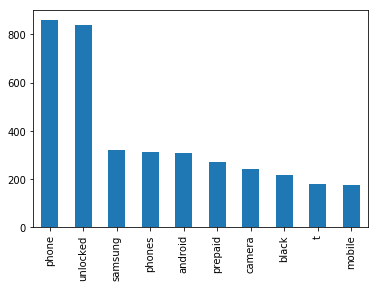

```python
vis['Count'].plot(kind='bar')
plt.show()
```

```python
dictionary_U2 = vis.to_dict()["Count"]
```

```python
dictionary_U2
```

```
{'android': 307,
 'black': 216,
 'camera': 240,
 'mobile': 176,
 'phone': 858,
 'phones': 314,
 'prepaid': 273,
 'samsung': 322,
 't': 178,
 'unlocked': 840}
```